# DATA 606 Homework 3

Ilya Kats

March 4, 2017

```r
library('DATA606')
```

### 3.2 Area under the curve, Part II.

1. $Z > -1.13$: The area is $1 - 0.1292381 = 0.8707619$ or $87.08\%$.

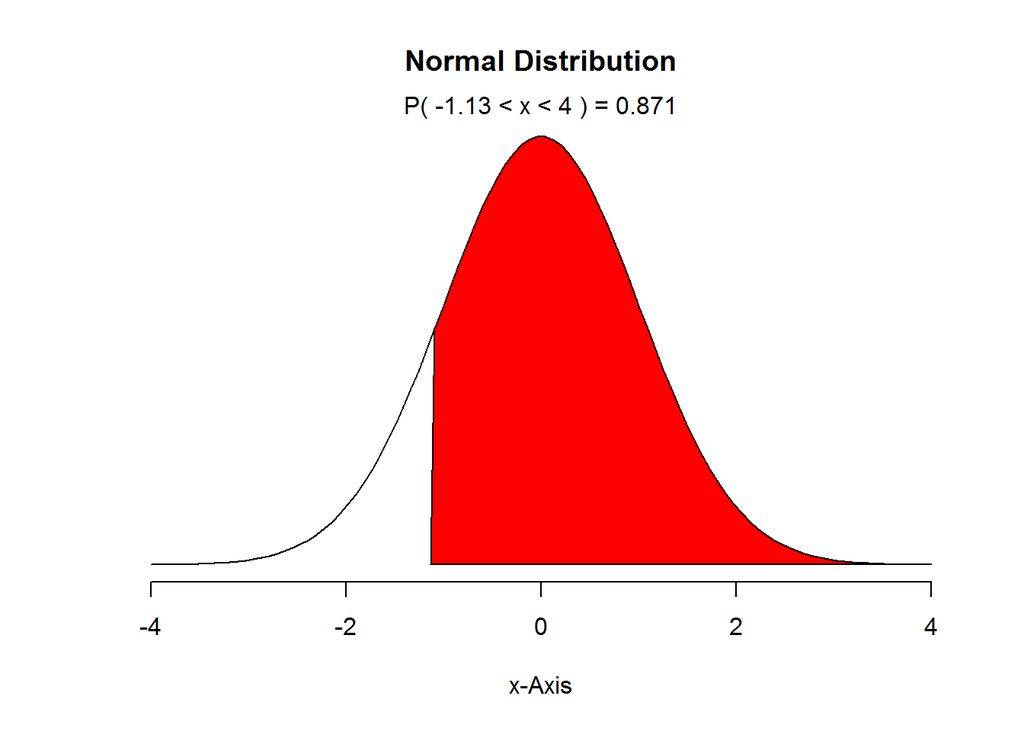

```r
normalPlot(mean = 0, sd = 1, bounds=c(-1.13,4), tails = FALSE)
```

2. $Z < 0.18$: The area is $0.5714237$ or $57.14\%$.

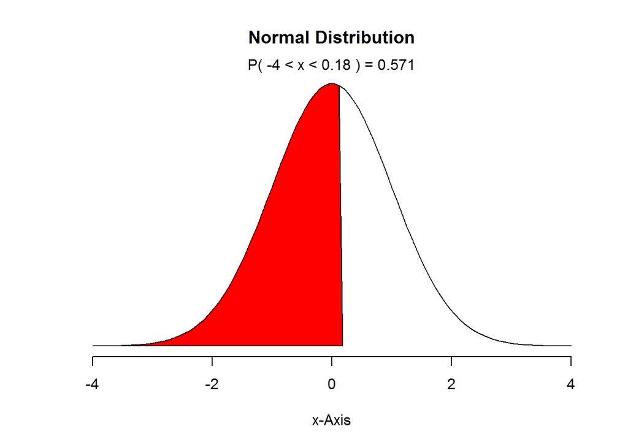

```r
normalPlot(mean = 0, sd = 1, bounds=c(-4,0.18), tails = FALSE)
```

3. $Z > 8$: The probability of a value in normal distribution being 8 standard deviations away from mean is well under $0.01\%$, so the area is almost nearly $0$.
4. $|Z| < 0.5$: The area is $0.6914625 - 0.3085375 = 0.3829249$ or $38.3\%$.

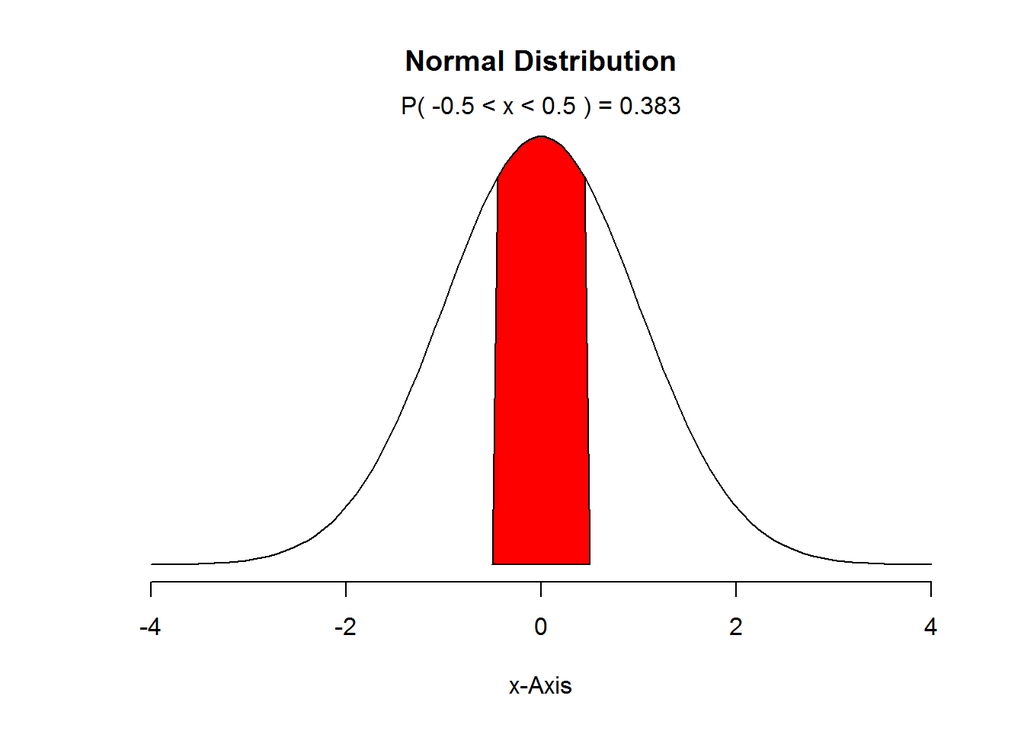

```r
normalPlot(mean = 0, sd = 1, bounds=c(-0.5,0.5), tails = FALSE)
```

### 3.4 Triathlon times, Part I.

1. Men, Ages 30-34: $N(\mu = 4313, \sigma = 583)$, and Women, Ages 25-29: $N(\mu = 5261, \sigma = 807)$.
2. ${Z}_{Leo} = \frac{x - \mu}{\sigma} = \frac{4948 - 4313}{583} \approx 1.0892$ and ${Z}_{Mary} = \frac{x - \mu}{\sigma} = \frac{5513 - 5261}{807} \approx 0.3123$; Leo finished the race about 1.09 standad deviations above the mean, while Mary finished the race about 0.31 standard deviations above the mean.

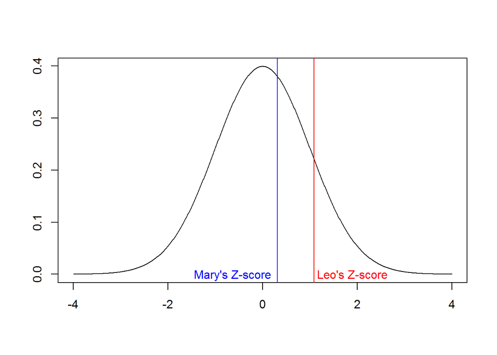

3. Please note that because a better performance corresponds to a faster finish, lower Z-scores correspond to better performance. **Mary ranked better** in her group since her Z-score is better than Leo’s.
4. Leo’s Z-score corresponds to probability $0.8619672$. Since higher Z-score corresponds to slower finish, Leo finished faster than $1 - 0.8619672 = 0.1380328$ or $13.8\%$.
5. Mary’s Z-score corresponds to probability $0.6225937$. Since higher Z-score corresponds to slower finish, Mary finished faster than $1 - 0.6225937 = 0.3774063$ or $37.74\%$.
6. If distributions are not nearly normal, then part (b) will remain the same since Z-scores can still be calculated. However, parts (d) and (e) rely on the normal model for calculations, so the results would change.

### 3.18 Heights of female college students.

```r
heights <- c(54, 55, 56, 56, 57, 58, 58, 59, 60, 60, 60, 61, 61,
             62, 62, 63, 63, 63, 64, 65, 65, 67, 67, 69, 73)
hgt_m <- mean(heights)
hgt_m
```

```
## [1] 61.52
```

```r
hgt_sd <- sd(heights)
hgt_sd
```

```
## [1] 4.583667
```

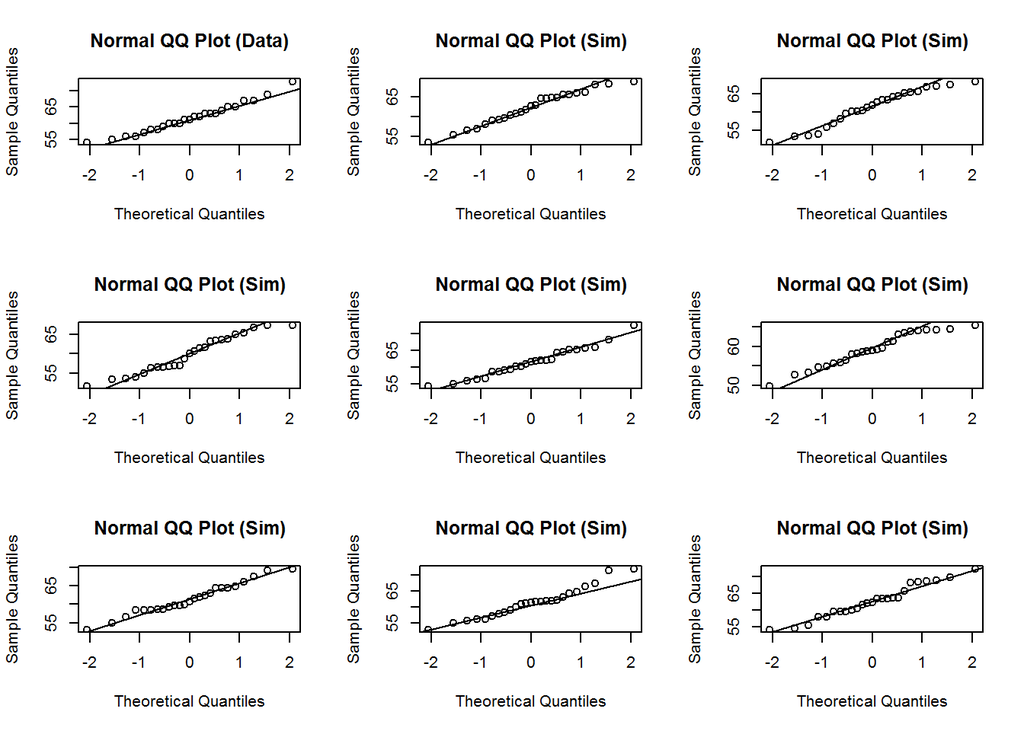

```r
qqnormsim(heights)
```

Looking at the QQ plots, the plot for actual data mostly follows the line with a few outliers at the edges. It appears better than some QQ plots for simulated data with normal distribution. As such I think we can conclude that the heights data follows a normal distribution.

```r
# Values one standard deviation away from mean
pnorm(hgt_m + hgt_sd, mean = hgt_m, sd = hgt_sd) -
  pnorm(hgt_m - hgt_sd, mean = hgt_m, sd = hgt_sd)
```

```
## [1] 0.6826895
```

```r
# Values two standard deviation away from mean
pnorm(hgt_m + 2 * hgt_sd, mean = hgt_m, sd = hgt_sd) -
  pnorm(hgt_m - 2 * hgt_sd, mean = hgt_m, sd = hgt_sd)
```

```
## [1] 0.9544997
```

```r
# Values three standard deviation away from mean
pnorm(hgt_m + 3 * hgt_sd, mean = hgt_m, sd = hgt_sd) -
  pnorm(hgt_m - 3 * hgt_sd, mean = hgt_m, sd = hgt_sd)
```

```
## [1] 0.9973002
```

Using normal distribution probability, we can confirm that the heights **follow the 68-95-99.7% rule very closely**.

### 3.22 Defective rate.

$p = 0.02$

1. $P(10th\ transistor\ is\ the\ first\ with\ a\ defect) = (1 - p)^{n-1} p = (1 - 0.02)^9 * 0.02 = 0.016675$
2. $P(no\ defects\ in\ a\ batch\ of\ 100) = (1 - p)^{100} = 0.98^{100} = 0.1326196$
3. $\mu = \frac{1}{p} = \frac{1}{0.02} = 50$ and $\sigma = \sqrt{\frac{1-p}{p^2}} = \sqrt{\frac{0.98}{0.0004}} = \sqrt{2450} = 49.4974747$
4. If $p = 0.05$, then $\mu = \frac{1}{0.05} = 20$ and $\sigma = \sqrt{\frac{0.95}{0.0025}} = 19.4935887$.
5. When probability of an event is higher, the event is more common, so the expected number of trials before it occurs and the standard deviation are lower.

### 3.38 Male children.

1. If $p = 0.51$, $n = 3$ and $k = 2$, then $P(two\ boys\ out\ of\ three\ kids) = \frac{n!}{k!(n-k)!} p^k (1-p)^{n-k} = \frac{3!}{2!} * 0.51^2 * 0.49 = 0.382347$.
2. Possible combinations include:
- boy, boy, girl
- boy, girl, boy
- girl, boy, boy

$P(two\ boys\ out\ of\ three\ kids)$

$=(P(boy)*P(boy)*P(girl))+(P(boy)*P(girl)*P(boy))+(P(girl)*P(boy)*P(boy))$

$=3*0.51*0.51*0.49 = 0.382347$

3. If using approach b to calculate the probability that a couple with 8 kids has 3 boys, it is first necessary to determine the number of combinations of having 3 boys among 8 kids. The list will be significantly longer than with 3 kids (in fact, there are 56 combinations). With approach a, all that is necessary is just to plug in the numbers into the formula.

### 3.42 Serving in volleyball.

$p = 0.15$

1. This is a negative binomial distribution (serves are independent with each one being either a success or a failure, probability of success is the same for each serve and the last serve is a success) with $n=10$ and $k=3$.

$P(3rd\ success\ on\ the\ 10th\ try) = {n-1 \choose k-1} p^k (1-p)^{n-k}$ $= \frac{9!}{2! * 7!} * 0.15^3 * 0.85^7 = 0.0389501$

2. Serves are independent events and previous outcomes have no effect on future events. The probability of the success on the 10th serve is 0.15.
3. Part a is looking for the probability of a specific combination of successes withing 10 serves. Although each serve is independent, we are considering all 10 serves in determining the probability of the desired pattern. Contrary to this part b is only concerned with one serve. Previous outcomes are irrelevant because events are independent.